# glmhmm metacognition

```r
library(reticulate)
use_condaenv("glmhmm")

source_python("python/glm_hmm.py")
```

```python
import numpy as np
import numpy.random as npr
import matplotlib.pyplot as plt
import ssm
#from ssm.util import find_permutation
```

Introduce the function create_psychometric in the R folder

```r
library(tidyverse)
library(broom)
library(dplyr)
library(R.matlab)

list.files("R", full.names = TRUE) |>
  walk(source)

create_psychometric <- function(.value) {
  tibble(signed_contrast = seq(-1, 1, .01)) |>
    mutate(prop = glm_logistic_fun(signed_contrast, .value))
}
```

| Download of data (Buno) |
| --- |

In experiment 2, a calibration procedure was added to maintain a constant level of performance both during the experiment and across participants

- stimulus refers to which group of dots (right or left) has more of them (check; the quantity of trials with more dots either on the left or right group varies from subject to subject).
- dot_diff is the difference of dots between stimuli (subject where asked which stimulus had more dots).
- confidence is the confidence scale meassured with a 11-point probabilistic rating scale (1=certainly wrong, 3=probably wrong, 5=maybe wrong, 7=maybe correct, 9=probably correct, 11=certainly correct)

I think that it is easier to use rename that colnames

It is more standard in R to use <- than = for assignment

I don’t think the serial_bias column is correct. You just need to have a column that is lag(response). From Ashwood: The third column in the design matrix was the animal’s choice on the previous trial …. (search in the article)

The independent variable is not properly calculated. The stimulus is the location of the stimulus (0: left, 1: right). You need to calculate signed_dot_diff. For that, you need to transform the 0 value of the stimulus to -1. Use something like

df |> mutate(stimulus = if_else(stimulus == 0, -1, 1))

and then multiply stimulus by dot_diff.

| subject | stimulus | response | confidence | RT | dot_diff | correct | trial | serial_bias |
| --- | --- | --- | --- | --- | --- | --- | --- | --- |
| 1 | 1 | 0 | 7 | 0.906 | 43 | 0 | 1 | 0 |
| 1 | 1 | 0 | 9 | 0.626 | 15 | 0 | 2 | 1 |
| 1 | 1 | 1 | 5 | 1.253 | 13 | 1 | 3 | 0 |
| 1 | 1 | 1 | 8 | 0.634 | 2 | 1 | 4 | 0 |
| 1 | 1 | 1 | 7 | 0.731 | 49 | 1 | 5 | 0 |
| 1 | 1 | 1 | 8 | 0.567 | 52 | 1 | 6 | 0 |
| 1 | 0 | 0 | 7 | 2.487 | 33 | 1 | 7 | 0 |
| 1 | 0 | 1 | 7 | 0.744 | 4 | 0 | 8 | 1 |
| 1 | 0 | 1 | 8 | 0.504 | 58 | 0 | 9 | 1 |
| 1 | 1 | 1 | 8 | 0.557 | 21 | 1 | 10 | 0 |

[output cut: 990 more lines]

| Download of data (Dani) |
| --- |

Estos datos permiten comparar los resultados globales de lo trials de cada sujeto con su puntuación en cada escala, pero no permite comparar los distintos estados dependiendo de las puntuaciones de las escalas.

No wntiendo qué es HDDM, a, t, v_inter, y v_delta.

```r
qnData
```

[output not shown]

[output cut: 34 more lines]

[output not shown]

```r
# create objects for variables from task performance data
id<-matrix(0,length(taskData$analyseddata),1) # subject id
age<-matrix(0,length(taskData$analyseddata),1)
gender<-matrix(0,length(taskData$analyseddata),1)
accuracy<-matrix(0,length(taskData$analyseddata),1) # accuracy
mRatio<-matrix(0,length(taskData$analyseddata),1)   # metacognitive efficiency
confMean<-matrix(0,length(taskData$analyseddata),1) # mean confidence
```

```r
# create objects for variables from task questionnaire data
qnid<-matrix(0,length(qnData$allqna),1) # subject id
zung<-matrix(0,length(qnData$allqna),1)
anxiety<-matrix(0,length(qnData$allqna),1)
ocir<-matrix(0,length(qnData$allqna),1)
leb<-matrix(0,length(qnData$allqna),1)
iq<-matrix(0,length(qnData$allqna),1)
bis<-matrix(0,length(qnData$allqna),1)
schizo<-matrix(0,length(qnData$allqna),1)
eat<-matrix(0,length(qnData$allqna),1)
apathy<-matrix(0,length(qnData$allqna),1)
alcohol<-matrix(0,length(qnData$allqna),1)
```

```r
# extracting data from allqna data file
# loop over for all subjects
for (i in 1:length(qnData$allqna))
{
  qnid[i] = qnData$allqna[[i]][[1]][,,1]$id
  zung[i] = qnData$allqna[[i]][[1]][,,1]$zung[,,1]$score #first brackets is subject number
  anxiety[i] = qnData$allqna[[i]][[1]][,,1]$anxiety[,,1]$score
  ocir[i] = qnData$allqna[[i]][[1]][,,1]$ocir[,,1]$score
  leb[i] = qnData$allqna[[i]][[1]][,,1]$leb[,,1]$score
  iq[i] = qnData$allqna[[i]][[1]][,,1]$iq[,,1]$score
  bis[i] = qnData$allqna[[i]][[1]][,,1]$bis[,,1]$score[,,1]$total
  schizo[i] = qnData$allqna[[i]][[1]][,,1]$schizo[,,1]$score[,,1]$total
  eat[i] = qnData$allqna[[i]][[1]][,,1]$eat[,,1]$score[,,1]$total
  apathy[i] = qnData$allqna[[i]][[1]][,,1]$apathy[,,1]$score
  alcohol[i] = qnData$allqna[[i]][[1]][,,1]$alcohol[,,1]$score
}
```

```r
# extracting data from analysed data
# loop over for all subjects
for (i in 1:length(taskData$analyseddata))
{
  id[i]=taskData$analyseddata[[i]][[1]][,,1]$data[1,4]
  age[i] =taskData$analyseddata[[i]][[1]][,,1]$data[1,2]
  gender[i]=taskData$analyseddata[[i]][[1]][,,1]$data[1,3]
  confMean[i] = mean(taskData$analyseddata[[i]][[1]][,,1]$data[,9])
  accuracy[i] = mean(taskData$analyseddata[[i]][[1]][,,1]$data[,6])
  mRatio[i] = taskData$analyseddata[[i]][[1]][,,1]$mratio
}
```

```r
# set gender as factor (male or female)
gender <- factor(gender)
```

```r
# create dataframe to store questionnaire data
qnFrame = data.frame(qnid, anxiety, eat, apathy, alcohol, zung, ocir, leb, iq, bis, schizo)
# create dataframe to store task performance data
taskFrame = data.frame(id,age,gender,confMean,accuracy,mRatio)
# merge all data together into one data frame
allData =merge(taskFrame, qnFrame,by.x=c("id"), by.y=c("qnid"))
# join HDDM variables to existing dataframe
allData=data.frame(allData,HDDMpara)
```

[output not shown]

[output cut: 487 more lines]

| s01 2 states |
| --- |

```r
s01_trials <- data_trials %>%
  filter(subject == 1) %>%
  mutate(session = 1,
         intercept = 1,
         signed_contrast = dot_diff) %>%
  ungroup() %>%
  select(session, correct, intercept, signed_contrast)

s01_trials
```

| session | correct | intercept | signed_contrast |
| --- | --- | --- | --- |
| 1 | 0 | 1 | 43 |
| 1 | 0 | 1 | 15 |
| 1 | 1 | 1 | 13 |
| 1 | 1 | 1 | 2 |
| 1 | 1 | 1 | 49 |
| 1 | 1 | 1 | 52 |
| 1 | 1 | 1 | 33 |
| 1 | 0 | 1 | 4 |
| 1 | 0 | 1 | 58 |
| 1 | 1 | 1 | 21 |

[output cut: 200 more lines]

```r
glm_hmm2_s01 <- s01_trials %>%
  glm_hmm_r(.num_states = 2)
glm_hmm2_s01
```

| session | correct | intercept | signed_contrast |
| --- | --- | --- | --- |
| 1 | 0 | 1 | 43 |
| 1 | 0 | 1 | 15 |
| 1 | 1 | 1 | 13 |
| 1 | 1 | 1 | 2 |
| 1 | 1 | 1 | 49 |
| 1 | 1 | 1 | 52 |
| 1 | 1 | 1 | 33 |
| 1 | 0 | 1 | 4 |
| 1 | 0 | 1 | 58 |
| 1 | 1 | 1 | 21 |

[output cut: 200 more lines]

```
$log_prob
[1] -162.5481

$log_prior
[1] -31.30678

$log_lik
[1] -131.2413

$n_par
[1] 6

$recovered_weights
```

| state | coef | value |
| --- | --- | --- |
| S1 | V1 | -0.06030112 |
| S1 | V2 | 0.01483537 |
| S2 | V1 | 0.08214764 |
| S2 | V2 | 0.02386791 |

```
$transitions_tengo_que_reordenar_segun_estados_ordenados
              [,1]          [,2]
[1,]  -0.008788103 -4.738747e+00
[2,] -12.612236834 -3.331009e-06

$posterior_probs
```

| session | trial | state | p |
| --- | --- | --- | --- |
| 1 | 1 | S1 | 1.000000e+00 |
| 1 | 1 | S2 | 1.375372e-09 |
| 1 | 2 | S1 | 9.984717e-01 |
| 1 | 2 | S2 | 1.528305e-03 |
| 1 | 3 | S1 | 9.966945e-01 |
| 1 | 3 | S2 | 3.305524e-03 |
| 1 | 4 | S1 | 9.951211e-01 |
| 1 | 4 | S2 | 4.878893e-03 |
| 1 | 5 | S1 | 9.936790e-01 |
| 1 | 5 | S2 | 6.321018e-03 |

[output cut: 410 more lines]

| state | n_trials | prop |
| --- | --- | --- |
| S1 | 113 | 0.5380952 |
| S2 | 97 | 0.4619048 |

```
NA
```

| state | coef | value |
| --- | --- | --- |
| S1 | V1 | -0.06030112 |
| S1 | V2 | 0.01483537 |
| S2 | V1 | 0.08214764 |
| S2 | V2 | 0.02386791 |

```r
psycho_2_s01 <- glm_hmm2_s01$recovered_weights |>
  group_by(state) |>
  reframe(create_psychometric(value))
```

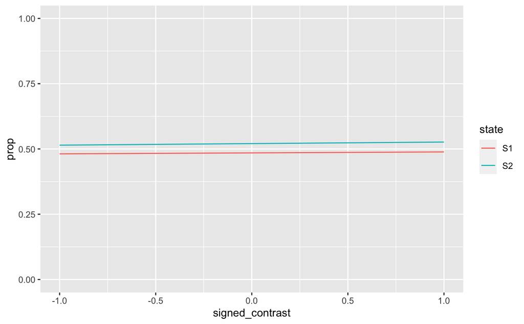

```r
psycho_2_s01 |>
  ggplot(aes(x = signed_contrast, y = prop, color = state)) +
  geom_line() +
  ylim(0, 1)
```

```r
glm_hmm2_s01$posterior_probs
```

| session | trial | state | p |
| --- | --- | --- | --- |
| 1 | 1 | S1 | 1.000000e+00 |
| 1 | 1 | S2 | 1.375372e-09 |
| 1 | 2 | S1 | 9.984717e-01 |
| 1 | 2 | S2 | 1.528305e-03 |
| 1 | 3 | S1 | 9.966945e-01 |
| 1 | 3 | S2 | 3.305524e-03 |
| 1 | 4 | S1 | 9.951211e-01 |
| 1 | 4 | S2 | 4.878893e-03 |
| 1 | 5 | S1 | 9.936790e-01 |
| 1 | 5 | S2 | 6.321018e-03 |

[output cut: 410 more lines]

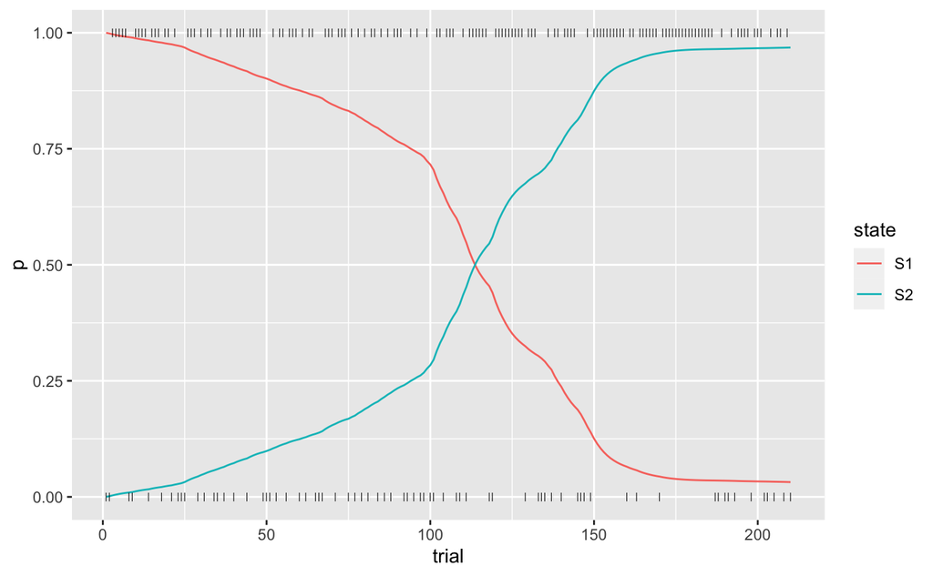

```r
ggplot() +
  geom_line(data = glm_hmm2_s01$posterior_probs,
            aes(x = trial, y = p, color = state)) +
  geom_point(data = filter(data_trials, subject == 1), aes(x = trial, y = correct), shape = "|")
```

Dos estados con diversas condiciones iniciales:

```r
glm_hmm2_s01 <- s01_trials %>%
  glm_hmm_r(.num_states = 2, .seeds = 1:20, .all_seeds = TRUE)

glm_hmm2_s01
```

```r
glm_hmm2_s01 %>%
  arrange(log_lik) %>%
  mutate(ordered_seed = row_number()) %>%
  ggplot(aes(ordered_seed, log_lik)) +
  geom_line() +
  geom_point()
```

| s01 3 states |
| --- |

```r
glm_hmm3_s01 <- s01_trials %>%
  glm_hmm_r(.num_states = 3, .seeds = 1:20)
glm_hmm3_s01
```

```r
psycho_3_s01 <- glm_hmm3_s01$recovered_weights |>
  group_by(state) |>
  reframe(create_psychometric(value))
```

No sé por qué no aparece la línea correspondiente al estado S1; también parece que no hay diferencia entre estados.

```r
psycho_3_s01 |>
  ggplot(aes(x = signed_contrast, y = prop, color = state)) +
  geom_line() +
  ylim(0, 1)
```

```r
ggplot() +
  geom_line(data = glm_hmm3_s01$posterior_probs,
            aes(x = trial, y = p, color = state)) +
  geom_point(data = s01_trials, aes(x = trial, y = correct), shape = "|")
```

Tres estados con diversas condiciones iniciales

```r
glm_hmm3_s01 <- s01_trials %>%
  glm_hmm_r(.num_states = 3, .seeds = 1:20, .all_seeds = TRUE)

glm_hmm3_s01
```

```r
glm_hmm3_s01 %>%
  arrange(log_lik) %>%
  mutate(ordered_seed = row_number()) %>%
  ggplot(aes(ordered_seed, log_lik)) +
  geom_line() +
  geom_point()
```

Aparece el siguiente error: Error in UseMethod(“logLik”) : no applicable method for ‘logLik’ applied to an object of class “c(‘tbl_df’, ‘tbl’, ‘data.frame’)” Creo que esto es por que alguna de las funciones de glm_hmm convierte al modelo en df.

```r
AIC(glm_hmm2_s01, glm_hmm3_s01)
```

| s01 serial bias 2 states |
| --- |

```r
s01_sb <- data_trials %>%
  filter(subject == 1) %>%
  mutate(session = 1,
         intercept = 1,
         signed_contrast = dot_diff) %>%
  ungroup() %>%
  select(session, serial_bias, intercept, signed_contrast, trial)

s01_sb
```

```r
glm_hmm2_s01_sb <- s01_sb %>%
  glm_hmm_r(.num_states = 2)
glm_hmm2_s01_sb
```

```r
glm_hmm2_s01_sb$recovered_weights
```

```r
psycho_2_s01_sb <- glm_hmm2_s01_sb$recovered_weights |>
  group_by(state) |>
  reframe(create_psychometric(value))
```

No sé si interpretar esto como que no hay diferencia entre dos estados o que estos son independientes del contraste mostrado.

```r
psycho_2_s01_sb |>
  ggplot(aes(x = signed_contrast, y = prop, color = state)) +
  geom_line() +
  ylim(0, 1)
```

```r
glm_hmm2_s01_sb$posterior_probs
```

Parece que se va cambiando de estado conforme más trial se realiza.

```r
ggplot() +
  geom_line(data = glm_hmm2_s01_sb$posterior_probs,
            aes(x = trial, y = p, color = state)) +
  geom_point(data = filter(data_trials, subject == 1), aes(x = trial, y = serial_bias), shape = "|")
```

Dos estados con diversas condiciones iniciales:

```r
glm_hmm2_s01_sb <- s01_sb %>%
  glm_hmm_r(.num_states = 2, .seeds = 1:20, .all_seeds = TRUE)

glm_hmm2_s01_sb
```

```r
glm_hmm2_s01_sb %>%
  arrange(log_lik) %>%
  mutate(ordered_seed = row_number()) %>%
  ggplot(aes(ordered_seed, log_lik)) +
  geom_line() +
  geom_point()
```

| s01 serial bias 3 states |
| --- |

```r
glm_hmm3_s01_sb <- s01_sb %>%
  glm_hmm_r(.num_states = 3)
glm_hmm3_s01_sb
```

```r
glm_hmm3_s01_sb$recovered_weights
```

```r
psycho_3_s01_sb <- glm_hmm3_s01_sb$recovered_weights |>
  group_by(state) |>
  reframe(create_psychometric(value))
```

Parece ser que estos estados son independientes del contraste mostrado.

```r
psycho_3_s01_sb |>
  ggplot(aes(x = signed_contrast, y = prop, color = state)) +
  geom_line() +
  ylim(0, 1)
```

```r
glm_hmm3_s01_sb$posterior_probs
```

Parece ser que los estados son dependientes de la cantidad de trials realizada y que S1 y S2 en este modelo corresponden al S1 del modelo de dos estados.

```r
ggplot() +
  geom_line(data = glm_hmm3_s01_sb$posterior_probs,
            aes(x = trial, y = p, color = state)) +
  geom_point(data = filter(data_trials, subject == 1), aes(x = trial, y = serial_bias), shape = "|")
```

Tres estados con diversas condiciones iniciales:

```r
glm_hmm3_s01_sb <- s01_sb %>%
  glm_hmm_r(.num_states = 3, .seeds = 1:20, .all_seeds = TRUE)

glm_hmm3_s01_sb
```

```r
glm_hmm3_s01_sb %>%
  arrange(log_lik) %>%
  mutate(ordered_seed = row_number()) %>%
  ggplot(aes(ordered_seed, log_lik)) +
  geom_line() +
  geom_point()
```

EL mismo error ocurre aquí; creo que aquí es porque la función glm_hmm_r lo convirtión en lista (línea 10 de esta función).

```r
AIC(glm_hmm2_s01_sb, glm_hmm3_s01_sb)
```

| 10 subjects sample 2 states |
| --- |

```r
rand_10_sub <- unique(data_trials$subject)
rand_10_sub <- rand_10_sub |>
  sample(10)

rand_10_sub_trials <- data_trials |>
  filter(subject %in% rand_10_sub) |>
  mutate(session = 1,
         intercept = 1,
         signed_contrast = dot_diff) |>
  ungroup() |>
  select(session, correct, intercept, signed_contrast)
```

```r
glm_hmm2_10 <- rand_10_sub_trials %>%
  glm_hmm_r(.num_states = 2, .seeds = 1:20)
glm_hmm2_10
```

```r
glm_hmm2_10$recovered_weights
```

```r
psycho_2_10 <- glm_hmm2_10$recovered_weights |>
  group_by(state) |>
  reframe(create_psychometric(value))
```

```r
psycho_2_10 |>
  ggplot(aes(x = signed_contrast, y = prop, color = state)) +
  geom_line() +
  ylim(0, 1)
```

```r
glm_hmm2_10$posterior_probs
```

Me parece que este chunk no se debe hacer con tantos sujetos

```r
ggplot() +
  geom_line(data = glm_hmm2_10$posterior_probs,
            aes(x = trial, y = p, color = state)) +
  geom_point(data = filter(data_trials, subject %in% rand_10_sub_trials), aes(x = trial, y = correct), shape = "|")
```

Dos estados con diversas condiciones iniciales:

```r
glm_hmm2_10 <- rand_10_sub_trials %>%
  glm_hmm_r(.num_states = 2, .seeds = 1:20, .all_seeds = TRUE)

glm_hmm2_10
```

```r
glm_hmm2_10 %>%
  arrange(log_lik) %>%
  mutate(ordered_seed = row_number()) %>%
  ggplot(aes(ordered_seed, log_lik)) +
  geom_line() +
  geom_point()
```

| 10 subjects sample 3 states |
| --- |

```r
glm_hmm3_10 <- rand_10_sub_trials %>%
  glm_hmm_r(.num_states = 3, .seeds = 1:20)
glm_hmm3_10
```

```r
glm_hmm3_10$recovered_weights
```

```r
psycho_3_10 <- glm_hmm3_10$recovered_weights |>
  group_by(state) |>
  reframe(create_psychometric(value))
```

```r
psycho_3_10 |>
  ggplot(aes(x = signed_contrast, y = prop, color = state)) +
  geom_line() +
  ylim(0, 1)
```

```r
glm_hmm3_10$posterior_probs
```

Me parece que este chunk no se debe hacer con tantos sujetos

```r
ggplot() +
  geom_line(data = glm_hmm3_10$posterior_probs,
            aes(x = trial, y = p, color = state)) +
  geom_point(data = filter(data_trials, subject %in% rand_10_sub_trials), aes(x = trial, y = correct), shape = "|")
```

```r
glm_hmm3_10 <- rand_10_sub_trials %>%
  glm_hmm_r(.num_states = 3, .seeds = 1:20, .all_seeds = TRUE)

glm_hmm3_10
```

```r
glm_hmm3_10 %>%
  arrange(log_lik) %>%
  mutate(ordered_seed = row_number()) %>%
  ggplot(aes(ordered_seed, log_lik)) +
  geom_line() +
  geom_point()
```

| 10 subjects serial bias 2 states |
| --- |

```r
rand_10_sub_sb <- data_trials |>
  filter(subject %in% rand_10_sub) |>
  mutate(session = 1,
         intercept = 1,
         signed_contrast = dot_diff) |>
  ungroup() |>
  select(session, serial_bias, intercept, signed_contrast)
```

```r
glm_hmm2_10_sb <- rand_10_sub_sb %>%
  glm_hmm_r(.num_states = 2)
glm_hmm2_10_sb
```

```r
glm_hmm2_10_sb$recovered_weights
```

```r
psycho_2_10_sb <- glm_hmm2_10_sb$recovered_weights |>
  group_by(state) |>
  reframe(create_psychometric(value))
```

No sé si interpretar esto como que no hay diferencia entre dos estados o que estos son independientes del contraste mostrado.

```r
psycho_2_10_sb |>
  ggplot(aes(x = signed_contrast, y = prop, color = state)) +
  geom_line() +
  ylim(0, 1)
```

```r
glm_hmm2_10_sb$posterior_probs
```

```r
ggplot() +
  geom_line(data = glm_hmm2_10_sb$posterior_probs,
            aes(x = trial, y = p, color = state)) +
  geom_point(data = filter(data_trials, subject %in% rand_10_sub_trials), aes(x = trial, y = serial_bias), shape = "|")
```

Dos estados con diversas condiciones iniciales:

```r
glm_hmm2_10_sb <- rand_10_sub_sb %>%
  glm_hmm_r(.num_states = 2, .seeds = 1:20, .all_seeds = TRUE)

glm_hmm2_10_sb
```

```r
glm_hmm2_10_sb %>%
  arrange(log_lik) %>%
  mutate(ordered_seed = row_number()) %>%
  ggplot(aes(ordered_seed, log_lik)) +
  geom_line() +
  geom_point()
```

| 10 subjects serial bias 3 states |
| --- |

```r
glm_hmm3_10_sb <- rand_10_sub_sb %>%
  glm_hmm_r(.num_states = 3)
glm_hmm3_10_sb
```

```r
glm_hmm3_10_sb$recovered_weights
```

```r
psycho_3_10_sb <- glm_hmm3_10_sb$recovered_weights |>
  group_by(state) |>
  reframe(create_psychometric(value))
```

No sé si interpretar esto como que no hay diferencia entre dos estados o que estos son independientes del contraste mostrado.

```r
psycho_3_10_sb |>
  ggplot(aes(x = signed_contrast, y = prop, color = state)) +
  geom_line() +
  ylim(0, 1)
```

```r
glm_hmm3_10_sb$posterior_probs
```

```r
ggplot() +
  geom_line(data = glm_hmm3_10_sb$posterior_probs,
            aes(x = trial, y = p, color = state)) +
  geom_point(data = filter(data_trials, subject %in% rand_10_sub_trials), aes(x = trial, y = serial_bias), shape = "|")
```

Dos estados con diversas condiciones iniciales:

```r
glm_hmm3_10_sb <- rand_10_sub_sb %>%
  glm_hmm_r(.num_states = 2, .seeds = 1:20, .all_seeds = TRUE)

glm_hmm3_10_sb
```

```r
glm_hmm3_10_sb %>%
  arrange(log_lik) %>%
  mutate(ordered_seed = row_number()) %>%
  ggplot(aes(ordered_seed, log_lik)) +
  geom_line() +
  geom_point()
```

| 30 subjects sample 2 states |
| --- |

```r
rand_30_sub <- unique(data_trials$subject)
rand_30_sub <- rand_30_sub |>
  sample(30)

rand_30_sub_trials <- data_trials |>
  filter(subject %in% rand_30_sub) |>
  mutate(session = 1,
         intercept = 1,
         signed_contrast = dot_diff) |>
  ungroup() |>
  select(session, correct, intercept, signed_contrast)
```

```r
glm_hmm2_30 <- rand_30_sub_trials %>%
  glm_hmm_r(.num_states = 2, .seeds = 1:20)
glm_hmm2_30
```

```r
glm_hmm2_30$recovered_weights
```

```r
psycho_2_30 <- glm_hmm2_30$recovered_weights |>
  group_by(state) |>
  reframe(create_psychometric(value))
```

Lo mismo aquí.

```r
psycho_2_30 |>
  ggplot(aes(x = signed_contrast, y = prop, color = state)) +
  geom_line() +
  ylim(0, 1)
```

```r
glm_hmm2_30$posterior_probs
```

Me parece que este chunk no se debe hacer con tantos sujetos

```r
ggplot() +
  geom_line(data = glm_hmm2_30$posterior_probs,
            aes(x = trial, y = p, color = state)) +
  geom_point(data = filter(data_trials, subject %in% rand_30_sub_trials), aes(x = trial, y = correct), shape = "|")
```

Dos estados con diversas condiciones iniciales:

```r
glm_hmm2_30 <- rand_30_sub_trials %>%
  glm_hmm_r(.num_states = 2, .seeds = 1:20, .all_seeds = TRUE)

glm_hmm2_30
```

```r
glm_hmm2_30 %>%
  arrange(log_lik) %>%
  mutate(ordered_seed = row_number()) %>%
  ggplot(aes(ordered_seed, log_lik)) +
  geom_line() +
  geom_point()
```

| 30 subjects sample 3 states |
| --- |

No logro correr esto

```r
glm_hmm3_30 <- rand_30_sub_trials %>%
  glm_hmm_r(.num_states = 3, .seeds = 1:20)
glm_hmm3_30
```

```r
glm_hmm3_30$recovered_weights
```

```r
psycho_3_30 <- glm_hmm3_30$recovered_weights |>
  group_by(state) |>
  reframe(create_psychometric(value))
```

```r
psycho_3_30 |>
  ggplot(aes(x = signed_contrast, y = prop, color = state)) +
  geom_line()
```

```r
glm_hmm3_30$posterior_probs
```

Me parece que este chunk no se debe hacer con tantos sujetos

```r
ggplot() +
  geom_line(data = glm_hmm3_30$posterior_probs,
            aes(x = trial, y = p, color = state)) +
  geom_point(data = filter(data_trials, subject %in% rand_30_sub_trials), aes(x = trial, y = correct), shape = "|")
```

```r
glm_hmm3_30 <- rand_30_sub_trials %>%
  glm_hmm_r(.num_states = 3, .seeds = 1:20, .all_seeds = TRUE)

glm_hmm3_30
```

```r
glm_hmm3_30 %>%
  arrange(log_lik) %>%
  mutate(ordered_seed = row_number()) %>%
  ggplot(aes(ordered_seed, log_lik)) +
  geom_line() +
  geom_point()
```

| 30 subjects serial bias 2 states |
| --- |

```r
rand_30_sub_sb <- data_trials |>
  filter(subject %in% rand_30_sub) |>
  mutate(session = 1,
         intercept = 1,
         signed_contrast = dot_diff) |>
  ungroup() |>
  select(session, serial_bias, intercept, signed_contrast)
```

```r
glm_hmm2_30_sb <- rand_30_sub_sb %>%
  glm_hmm_r(.num_states = 2)
glm_hmm2_30_sb
```

```r
glm_hmm2_30_sb$recovered_weights
```

```r
psycho_2_30_sb <- glm_hmm2_30_sb$recovered_weights |>
  group_by(state) |>
  reframe(create_psychometric(value))
```

No sé si interpretar esto como que no hay diferencia entre dos estados o que estos son independientes del contraste mostrado.

```r
psycho_2_30_sb |>
  ggplot(aes(x = signed_contrast, y = prop, color = state)) +
  geom_line() +
  ylim(0, 1)
```

```r
glm_hmm2_30_sb$posterior_probs
```

```r
ggplot() +
  geom_line(data = glm_hmm2_30_sb$posterior_probs,
            aes(x = trial, y = p, color = state)) +
  geom_point(data = filter(data_trials, subject %in% rand_30_sub_trials), aes(x = trial, y = serial_bias), shape = "|")
```

Dos estados con diversas condiciones iniciales:

```r
glm_hmm2_30_sb <- rand_30_sub_sb %>%
  glm_hmm_r(.num_states = 2, .seeds = 1:20, .all_seeds = TRUE)

glm_hmm2_30_sb
```

```r
glm_hmm2_30_sb %>%
  arrange(log_lik) %>%
  mutate(ordered_seed = row_number()) %>%
  ggplot(aes(ordered_seed, log_lik)) +
  geom_line() +
  geom_point()
```

| 30 subjects serial bias 3 states |
| --- |

```r
glm_hmm3_30_sb <- rand_30_sub_sb %>%
  glm_hmm_r(.num_states = 3)
glm_hmm3_30_sb
```

```r
glm_hmm3_30_sb$recovered_weights
```

```r
psycho_3_30_sb <- glm_hmm3_30_sb$recovered_weights |>
  group_by(state) |>
  reframe(create_psychometric(value))
```

No sé si interpretar esto como que no hay diferencia entre dos estados o que estos son independientes del contraste mostrado.

```r
psycho_3_30_sb |>
  ggplot(aes(x = signed_contrast, y = prop, color = state)) +
  geom_line() +
  ylim(0, 1)
```

```r
glm_hmm3_30_sb$posterior_probs
```

```r
ggplot() +
  geom_line(data = glm_hmm3_30_sb$posterior_probs,
            aes(x = trial, y = p, color = state)) +
  geom_point(data = filter(data_trials, subject %in% rand_30_sub_trials), aes(x = trial, y = serial_bias), shape = "|")
```

Dos estados con diversas condiciones iniciales:

```r
glm_hmm3_30_sb <- rand_30_sub_sb %>%
  glm_hmm_r(.num_states = 2, .seeds = 1:20, .all_seeds = TRUE)

glm_hmm3_30_sb
```

```r
glm_hmm3_30_sb %>%
  arrange(log_lik) %>%
  mutate(ordered_seed = row_number()) %>%
  ggplot(aes(ordered_seed, log_lik)) +
  geom_line() +
  geom_point()
```